# Register Variation and Exploratory Factor Analysis

Erin M. Buchanan

Last Knitted: 2021-12-22

# Language Topics Discussed

- Registers as an extension of dialect and other cultural norms
- The Linguistic Inquiry and Word Count (LIWC) will be used for the assignment

# Registers?

- A register is a language variety associated with the way you are using the language (i.e., email versus face-to-face)
- Contextual factors that change registers:
  - Communication channel: writing, speech
  - Relationship between participants: personal, work, status
  - Communication purpose: social, transfer of information
  - Setting: Private, public

# Registers are linguistic

- Registers can also be related to specific linguistic features
  - So we may see more first person pronouns in person than through email
  - We can use clustering to understand these conversations and give them labels without hand coding it

# Biber’s work

- Biber (1988) used factor analysis to analyze conversations for different register variations
  - Showed dimensions such as:
    - Involved/Informal Production
    - Narrative/Non-narrative contexts

# Relation to previous work

- These variations are obviously related to each other, rather than being distinct categories that we can cleanly separate
- This sort of overlap does make defining register difficult, but the general categories remain
- The idea of register is often tied to genre, stylistic choices, jargon, dialect (as defined last week)
- Sometimes defined as pragmatics - the social use of language

# Thinking about formality

- Register can be considered a ranking of formality (tenor), if we think about it in a social way
  - Frozen: “static” text, like the Pledge of Allegiance
  - Formal: one way conversation aimed at delivering technical knowledge, like a conference presentation
  - Consultative: two way conversation with some formality usually delivering knowledge, like student/teacher
  - Casual: friends/acquaintances, slang, social settings
  - Intimate: family, close friends, non-verbal messages, non-public

# Analyzing register

# Let’s look at the data

```r
##r chunk
library(reticulate)
library(Rling)
library(psych)
data(reg_bnc)
head(reg_bnc)
```

```
##                Reg     Ncomm       Nprop      Vpres      Vpast         P1
## S_brdcst_disc Spok 0.1696076 0.026968511 0.03550390 0.02186820 0.03472018
## S_brdcst_doc  Spok 0.2050599 0.024979040 0.03910835 0.02976279 0.02083642
## S_brdcst_news Spok 0.2055274 0.046801903 0.03663561 0.02357982 0.01798168
## S_classroom   Spok 0.1362944 0.011201051 0.04851445 0.01888829 0.02762069
## S_consult     Spok 0.1327101 0.009851242 0.04519086 0.01983190 0.04552583
## S_conv        Spok 0.1197967 0.019950370 0.04425219 0.03748277 0.04436459
##                        P2        Adj  ConjCoord    ConjSub   Interject
## S_brdcst_disc 0.018323103 0.05357844 0.03949722 0.03104469 0.009968366
## S_brdcst_doc  0.011367559 0.05851457 0.03397939 0.02764216 0.004142625
## S_brdcst_news 0.007748555 0.05961002 0.03347093 0.02323387 0.002256555
## S_classroom   0.037485571 0.04069626 0.03388688 0.03145703 0.021732804
## S_consult     0.037029706 0.04460466 0.03840766 0.02828235 0.042975471
## S_conv        0.033902170 0.03814620 0.03243399 0.02375677 0.042791736
##                      Num
## S_brdcst_disc 0.02060500
## S_brdcst_doc  0.01915964
## S_brdcst_news 0.02768015
## S_classroom   0.04138981
## S_consult     0.01642889
## S_conv        0.02060458
```

```python
##python chunk

#open library
import pandas as pd

#move over data from R or import it with pd.read_csv
reg_bnc_py = r.reg_bnc

#look at the data
reg_bnc_py.head()

#get rid of extra columns we don't need
```

```
##                 Reg     Ncomm     Nprop  ...   ConjSub  Interject       Num
## S_brdcst_disc  Spok  0.169608  0.026969  ...  0.031045   0.009968  0.020605
## S_brdcst_doc   Spok  0.205060  0.024979  ...  0.027642   0.004143  0.019160
## S_brdcst_news  Spok  0.205527  0.046802  ...  0.023234   0.002257  0.027680
## S_classroom    Spok  0.136294  0.011201  ...  0.031457   0.021733  0.041390
## S_consult      Spok  0.132710  0.009851  ...  0.028282   0.042975  0.016429
##
## [5 rows x 12 columns]
```

```python
reg_bnc_py.drop(['Reg'], axis = 1, inplace = True)
```

# A brief note

- PCA: components are orthogonal (i.e. uncorrelated) linear combinations that maximize capturing the total variance
  - Often used when you want separate distinction solutions, clustering things together, dimensionality reduction
  - Components are not interpretable
- EFA: factors are linear combinations that maximize the shared portions of the variance
  - Often used when you want to identify the underlying “latent” variables, allowing them to be correlated to each other
  - Factors are interpretable and labelable
- We are going to focus on EFA in this analysis!

# Steps to Analysis

- Things to check before you begin
- How many factors should you use?
- Simple structure
- Adequate solutions

# Before you begin

- Check correlations - you want things to be correlated, `cortest.bartlett`
- Check your sampling adequacy, `KMO`
- At least 3-4 items per grouping
- Interval measurement
- Normal/linear/normal parametric assumptions

# Correlations

- If non-significant implies that your items are not correlated enough

```r
##r chunk
correlations <- cor(reg_bnc[ , -1 ])
cortest.bartlett(correlations, n = nrow(reg_bnc))
```

```
## $chisq
## [1] 536.3401
##
## $p.value
## [1] 0.00000000000000000000000000000000000000000000000000000000000000000000000000000004109611
##
## $df
## [1] 55
```

# Correlations - Python

- If you see a `TypeError: Series cannot perform the operation -`: you have tried to pass character columns to the correlation matrix, which does not work.

```python
##python chunk

#import bartlett test
from factor_analyzer.factor_analyzer import calculate_bartlett_sphericity

#calculate bartlett
chi_square_value, p_value = calculate_bartlett_sphericity(reg_bnc_py)

#output the answer
chi_square_value, p_value
```

```
## (546.5373635160918, 4.124515213919112e-82)
```

# Sampling adequacy

- Kaiser-Meyer-Olkin (KMO) test
- Compares the ratio between $r^2$ and $pr^2$
- Scores closer to 1 are better, closer to 0 are bad

# Sampling adequacy

```r
##r chunk
KMO(correlations)
```

```
## Kaiser-Meyer-Olkin factor adequacy
## Call: KMO(r = correlations)
## Overall MSA =  0.72
## MSA for each item =
##     Ncomm     Nprop     Vpres     Vpast        P1        P2       Adj ConjCoord
##      0.85      0.61      0.61      0.29      0.86      0.88      0.78      0.49
##   ConjSub Interject       Num
##      0.72      0.76      0.53
```

```python
##python chunk
from factor_analyzer.factor_analyzer import calculate_kmo
kmo_all,kmo_model=calculate_kmo(reg_bnc_py)

#for each variable one at a time
kmo_all

#for the entire set
```

```
## array([0.8466268 , 0.60685352, 0.60141667, 0.28704038, 0.8518912 ,
##        0.87230151, 0.77283103, 0.47977265, 0.7162535 , 0.75291392,
##        0.52250951])
```

```python
kmo_model
```

```
## 0.7163568115936928
```

# How many factors do I use?

- Theory
- Kaiser criterion
- Scree plots
- Parallel analysis

# Kaiser criterion

- Old rule: extract the number of eigenvalues over 1
- New rule: extract the number of eigenvalues over .7
- What the heck is an eigenvalue?
  - A mathematical representation of the variance accounted for by that grouping of items

# Scree plots

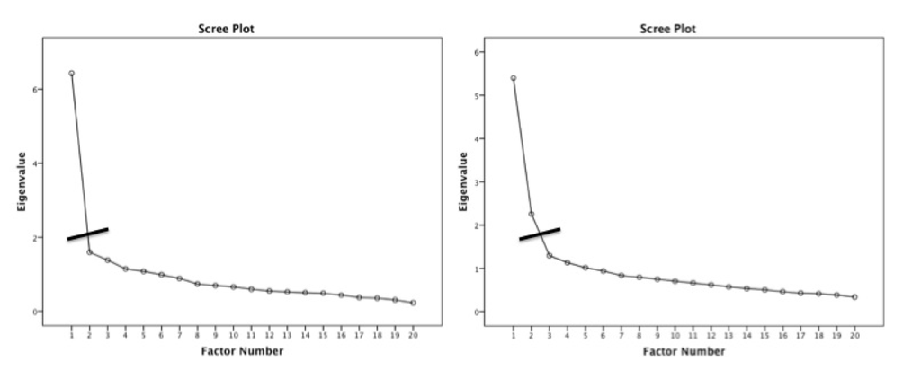

# Parallel analysis

- A statistical test to tell you how many eigenvalues are greater than chance
  - Calculates the eigenvalues for your data
  - Randomizes your data and recalculates the eigenvalues
  - Then compares them to determine if they are equal

# Finding factors/components

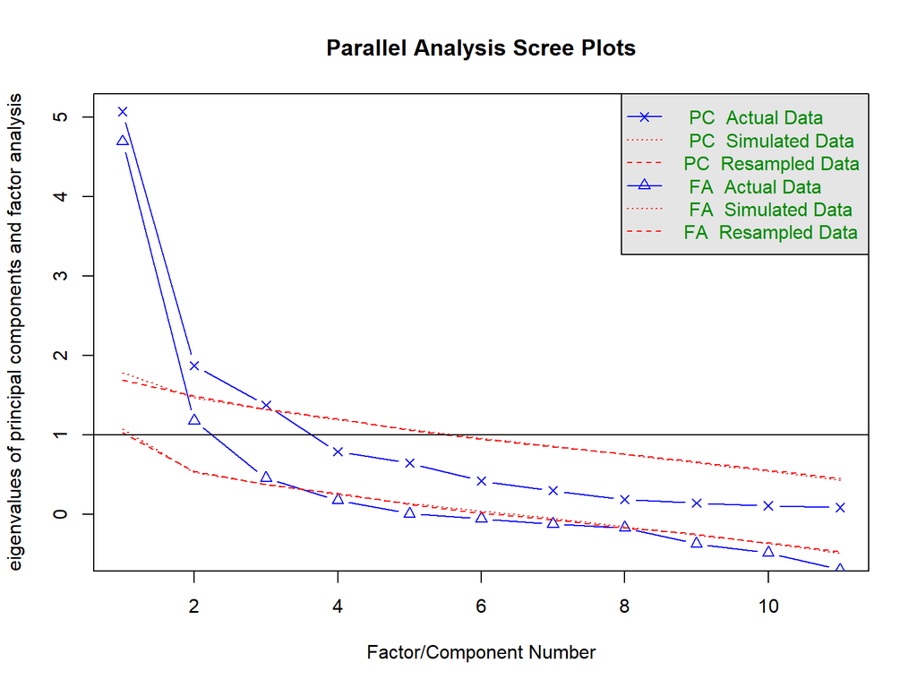

```
## Parallel analysis suggests that the number of factors =  3  and the number of components =  2
```

```r
##r chunk
number_items <- fa.parallel(reg_bnc[, -1], ##dataset
                           fm = "ml", ##type of math
                           fa = "both") #look at both efa/pca
```

# Finding factors/components - Python

```python
##python chunk
#save factor analysis function
from factor_analyzer import FactorAnalyzer
fa = FactorAnalyzer(n_factors = len(reg_bnc_py.columns),
                    rotation = None)

#run an analysis just to get the eigenvalues
fa.fit(reg_bnc_py)

#view the eigenvalues
```

```
## FactorAnalyzer(n_factors=11, rotation=None, rotation_kwargs={})
```

```python
ev, v = fa.get_eigenvalues()
ev
```

```
## array([5.0682936 , 1.87221031, 1.37584355, 0.79007568, 0.64512706,
##        0.42171443, 0.30027045, 0.18666203, 0.14370361, 0.10877509,
##        0.08732419])
```

# Scree Plots - Python

```python
##python chunk
import matplotlib
```

[output not shown]

```python
matplotlib.use('Agg')
from matplotlib import pyplot as plt

plt.scatter(range(1,reg_bnc_py.shape[1]+1),ev)
plt.plot(range(1,reg_bnc_py.shape[1]+1),ev)
plt.title('Scree Plot')
plt.xlabel('Factors')
plt.ylabel('Eigenvalue')
plt.grid()
plt.show()
```

[output not shown]

# Eigenvalues

```r
##r chunk
sum(number_items$fa.values > 1)
```

```
## [1] 2
```

```r
sum(number_items$fa.values > .7)
```

```
## [1] 2
```

```python
##python chunk
sum(ev > 1)
```

```
## 3
```

```python
sum(ev > .7)
```

```
## 4
```

# Simple structure

- Simple structure covers two pieces:
  - The math used to achieve the solution
    - PCA: principle components
    - EFA: maximum likelihood
  - The rotation to increase communality between items and aid in interpretation (EFA only)

# Rotation

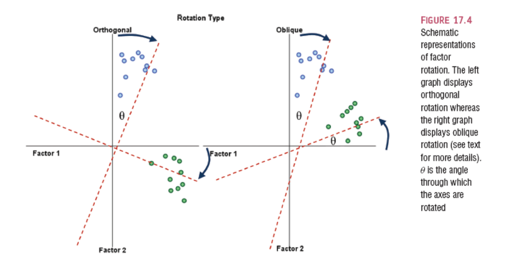

# Rotation

- Orthogonal assume uncorrelated factors: varimax, quartermax, equamax
- Oblique allows factors to be correlated: oblimin, promax
- Why would we even use orthogonal?

# Simple structure/solution

- Looking at the loadings: the relationship between the item and the factor/component
  - Want these to be related at least .3
  - Remember that r = .3 is a medium effect size that is ~10% variance
  - Can eliminate items that load poorly
  - Difference here in scale development versus exploratory clustering

# Run an EFA

```r
##r chunk
EFA_fit <- fa(reg_bnc[, -1], #data
             nfactors = 2, #number of factors
             rotate = "oblimin", #rotation
             fm = "ml") #math
```

```python
##python chunk
fa = FactorAnalyzer(n_factors = 2, rotation = "oblimin")
fa.fit(reg_bnc_py)
```

```
## FactorAnalyzer(n_factors=2, rotation='oblimin', rotation_kwargs={})
```

# Look at the results

```r
##r chunk
EFA_fit$loadings #look at the full results
```

```
##
## Loadings:
##           ML1    ML2
## Ncomm     -0.955
## Nprop            -0.885
## Vpres      0.324  0.363
## Vpast      0.288 -0.507
## P1         0.845  0.152
## P2         0.722  0.336
## Adj       -0.974  0.196
## ConjCoord         0.510
## ConjSub    0.336  0.599
## Interject  0.677  0.196
## Num              -0.306
##
##                  ML1   ML2
## SS loadings    3.862 2.101
## Proportion Var 0.351 0.191
## Cumulative Var 0.351 0.542
```

```r
EFA_fit
```

```
## Factor Analysis using method =  ml
## Call: fa(r = reg_bnc[, -1], nfactors = 2, rotate = "oblimin", fm = "ml")
## Standardized loadings (pattern matrix) based upon correlation matrix
##             ML1   ML2   h2   u2 com
## Ncomm     -0.96  0.06 0.88 0.12 1.0
## Nprop      0.01 -0.89 0.78 0.22 1.0
## Vpres      0.32  0.36 0.32 0.68 2.0
## Vpast      0.29 -0.51 0.24 0.76 1.6
## P1         0.85  0.15 0.83 0.17 1.1
## P2         0.72  0.34 0.80 0.20 1.4
## Adj       -0.97  0.20 0.86 0.14 1.1
## ConjCoord -0.04  0.51 0.25 0.75 1.0
## ConjSub    0.34  0.60 0.61 0.39 1.6
## Interject  0.68  0.20 0.59 0.41 1.2
## Num       -0.07 -0.31 0.11 0.89 1.1
##
##                        ML1  ML2
## SS loadings           4.01 2.25
## Proportion Var        0.36 0.20
## Cumulative Var        0.36 0.57
## Proportion Explained  0.64 0.36
## Cumulative Proportion 0.64 1.00
##
##  With factor correlations of
##      ML1  ML2
## ML1 1.00 0.34
## ML2 0.34 1.00
##
## Mean item complexity =  1.3
## Test of the hypothesis that 2 factors are sufficient.
##
## The degrees of freedom for the null model are  55  and the objective function was  8.45 with Chi Square of  536.34
## The degrees of freedom for the model are 34  and the objective function was  1.72
##
## The root mean square of the residuals (RMSR) is  0.09
## The df corrected root mean square of the residuals is  0.11
##
## The harmonic number of observations is  69 with the empirical chi square  60.62  with prob <  0.0033
## The total number of observations was  69  with Likelihood Chi Square =  106.92  with prob <  0.0000000018
##
## Tucker Lewis Index of factoring reliability =  0.749
## RMSEA index =  0.176  and the 90 % confidence intervals are  0.14 0.216
## BIC =  -37.04
## Fit based upon off diagonal values = 0.96
## Measures of factor score adequacy
##                                                    ML1  ML2
## Correlation of (regression) scores with factors   0.98 0.93
## Multiple R square of scores with factors          0.96 0.87
## Minimum correlation of possible factor scores     0.92 0.74
```

# Look at the results - Python

```python
##python chunk
fa.loadings_ #notice underscore
```

```
## array([[-0.95661051,  0.03587681],
##        [ 0.03721055, -0.87366796],
##        [ 0.241146  ,  0.48734021],
##        [ 0.27452615, -0.47551809],
##        [ 0.82784698,  0.17957616],
##        [ 0.71153141,  0.35625783],
##        [-0.98283784,  0.19897485],
##        [-0.01905488,  0.45813351],
##        [ 0.27893283,  0.62419873],
##        [ 0.68397449,  0.16631985],
##        [-0.04794366, -0.33156555]])
```

```python
fa.get_factor_variance() ##ss, prop, cumulative
```

```
## (array([3.7558684, 2.1640674]), array([0.34144258, 0.1967334 ]), array([0.34144258, 0.53817598]))
```